# Mann-Whitney Test using SPSS

Mann-Whitney Test using SPSS

## When to use a Mann-Whitney Test

A Mann-Whitney test is used to assess whether the values of an Ordinal outcome variable differ between two groups.

**Example:**

We might ask participants if they agree with a statement in a questionnaire, responding using a 5-point Likert scale:

1. Strongly Disagree
2. Disagree
3. Neither disagree nor agree
4. Agree
5. Strongly Agree

We wish to see if males agree more than females or vice-versa.

These coded responses 1 to 5 do not represent a scale but instead are ordered categories and so that data is Ordinal.

**Comparing groups for ordinal outcomes**

Since we want to compare two groups for an ordinal outcome we could use a Mann-Whitney test. To compare more than two groups, consider using a Kruskal Wallis test.

A Mann-Whitney test can also be used when the outcome variable is Scale (e.g. calorie intake or blood pressure etc.) but a better test would be a Two Sample t-test. However, that t-test test makes an assumption about normality and if that assumption is in doubt, then a Mann-Whitney test would be a good alternative.

For more help on “What test do I need” go to the **sigma** website [statistical worksheets resources](https://libguides.coventry.ac.uk/c.php?g=712076&p=5146769) page.

## Example

A study asked participants to rate various aspects of a new mobile phone, on an ordinal scale of 1 to 10 where 1 indicated they felt this aspect had “low importance”, up to 10 to indicate “high importance”. The data shown below can be downloaded in an SPSS file called phone.sav and shows columns for the rating scores for price, ease of use, look, etc.

[figure not shown]

We are interested in whether the price rating tends to be higher or lower amongst males compared to females. Since the price score is Ordinal and we wish to compare two groups we should use a Mann-Whitney test.

## Using SPSS

To perform the Mann-Whitney test, from the **Main Menu**, click the **Analyze** menu then select **Nonparametric Tests**, then **Legacy Dialogs** and then **2 Independent Samples**:

[figure not shown]

In the next dialogue window, move Price Score (the outcome variable) to the **Test Variable List** box. Next, move gender to the **Grouping Variable** box:

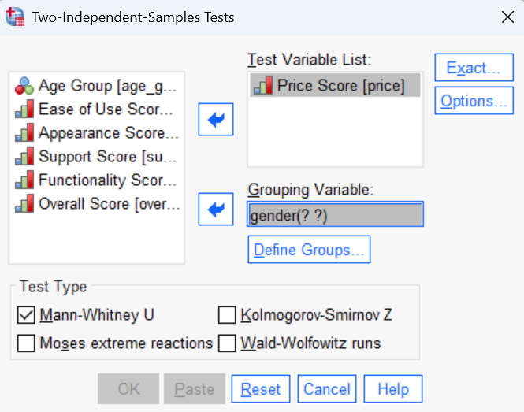

You will need to click on the **Define Groups** button above to choose which two groups to compare.

In the next dialogue box (shown below) enter the numeric values (coded male=1, and female=2):

[figure not shown]

Click **Continue** and then finally, click **OK**.

## Examining the Output

The Research Question is: Is there a difference in the price scores for males and females?

The Mann-Whitney test answers this by testing the hypotheses:

H0: There is no difference in the distribution of price scores

H1: There is a difference in the distribution of price scores

The table below provides the main results of our test:

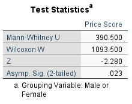

The row labelled **Asymp. Sig (2-tailed)** provides you with your p-value which is 0.023. This is less than 0.05 so there is evidence in favour of H1 that is there is a difference in the price scores between males and females. Note also the value in the Z row of -2.280. This is the test statistic from which the p-value is derived and is also often included when reporting the results.

To see if males or females tended to rate price more importantly, we could use the other table in the output:

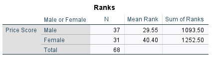

This shows that the mean rank was higher for females, meaning that they gave higher price scores and hence consider price more important than males. Ranks are reported here since the Mann-Whitney test is based on comparing the ranked scores.

If you struggle with ranks, then you can instead obtain the median scores as follows:

From the **Main Menu**, click the **Analyze** menu then select **Compare means**, then **Means**:

[figure not shown]

In the next dialogue window, move Price Score (the outcome variable) to the **Dependent List** box. Next, move gender to the **Independent List** box, then click on the Options button:

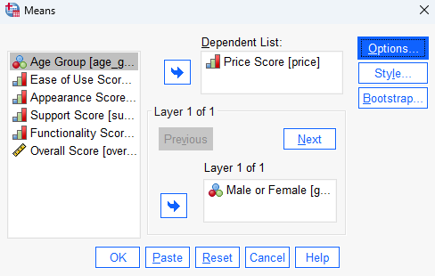

In the next dialogue window, move **Median** to the **Cell Statistics** box:

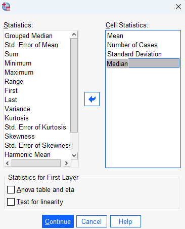

Click **Continue** and then finally, click **OK**.

The table in the output looks as follows:

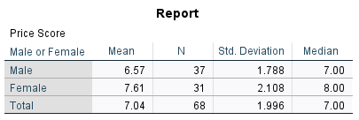

We can see that the average (median) score was higher at 8 for females compared to 7 for males. If the medians were the same, but the Mann-Whitney test had indicated a significant difference, then we could look at the means, or even compare histograms to understand better what the difference is.

## Reporting Results

We could write the results as:

*“A Mann-Whitney t-test was used to compare the price scores for males and females. The difference was statistically significant (Z = -2.280, p = 0.023) and females tended to score price as more important (Median = 8) compared to males (Median = 7).”*

## Closing Note

Whilst we often report medians in the results section when using a Mann-Whitney test, the test does not formally test whether there is a difference in the medians between the two groups, despite large amounts of information on the internet incorrectly suggesting it does. The test actually compares the distribution of the Ordinal outcome between two groups.

For more resources, see sigma.coventry.ac.uk Adapted from material developed by Coventry University